# Topic Model Workshop - Part 3 (STM)

Ryan Wesslen

Nov 27, 2017

## Load the data

Let’s start by loading our packages and loading the dataset.

```r
library(quanteda); library(tidyverse); library(RColorBrewer); library(stm)

dataset <- read_csv("./articles-sample.csv")

#create corpus
myCorpus <- corpus(dataset$Abstract)
docvars(myCorpus, field = "Subject") <- ifelse(dataset$College=="Computing and Informatics",
                                               "Computing","Social Science")
docvars(myCorpus, field = "Year") <- as.integer(dataset$Year)
```

## Create the dfm (pre-processing)

```r
stopWords <- c("can","use","uses","used","using","study","studies","first","second","third","also","across","results","result","resulted","may","however","one","two","three","four","five","among","well","within","many","related","i.e","e.g","find","finding","finds","found","increase","increases","increasing","increased","decreased","decrease","decreases","decreasing","propose","proposal","proposals","proposes","proposed","new","old","differ","differs","different","difference","differences","positive","negative","findings","reports","report","reported","state","states","article","articles","examines","examine","suggest","research","researches","researchers","need","needs","show","shows","association","associations","associated","discuss","discusses","discussed","will","likely","unlikely","paper","method","methods","methodology","compared","specifically","approach","impact","impacts","examine","examined","examines","includes","include","included","including","measure","measures","measured","analysis","analyze","analyses","complete","completes","completed","indicate","indicated","indicates","high","higher","low","lower","follow","follows","following","significant","significance","approach","approaches","approached","model","models","demonstrate","demonstrated","demonstrates","yet","best","worst","better","large","small","larger","smaller","several","few","much","less","given","via","long","short","often","years","along","whether","potential","significantly","influence","influenced","influences","develop","develops","developed","good","bad","based","p","group","groups","effect","affect","affects","effects","sample","samples","relationship","relationships","change","changes","m","k","conclusion","conclusions","present","presents")

dfm <- dfm(myCorpus,
           remove = c(stopwords("english"), stopWords),
           ngrams= 1L,
           stem = F,
           remove_numbers = TRUE,
           remove_punct = TRUE,
           remove_symbols = TRUE)
```

## Structural Topic Model: Subject and Year

For this part, we’re going to use the `stm` package to introduce two covariates into our model: field (Computing or Social Science) and year.

```r
library(stm)

# use quanteda converter to convert our Dfm
stmdfm <- convert(dfm, to = "stm", docvars = docvars(myCorpus))
```

Unlike the `topicmodels` packages, `stm` has built in features to help analysts reduce sparse terms (minDoc or minCount).

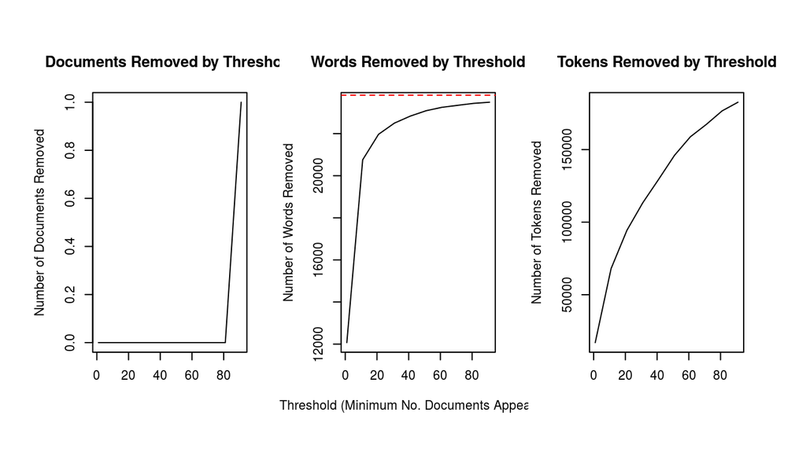

```r
plotRemoved(stmdfm$documents, lower.thresh = seq(1, 100, by = 10))
```

```r
out <- prepDocuments(stmdfm$documents, stmdfm$vocab, stmdfm$meta, lower.thresh = 5)
```

```
## Removing 18741 of 23827 terms (31117 of 182292 tokens) due to frequency
## Your corpus now has 2879 documents, 5086 terms and 151175 tokens.
```

Let’s run a 40 topic model.

```r
k <- 40
load("./stmFit.RData")

#stmFit <- stm(out$documents, out$vocab, K = k, prevalence =~ s(Year) + Subject,
#              max.em.its = 150, data = out$meta, init.type = "Spectral", seed = 300)

#save(stmFit, file = "./stmFit.RData")
```

Let’s explore the topics.

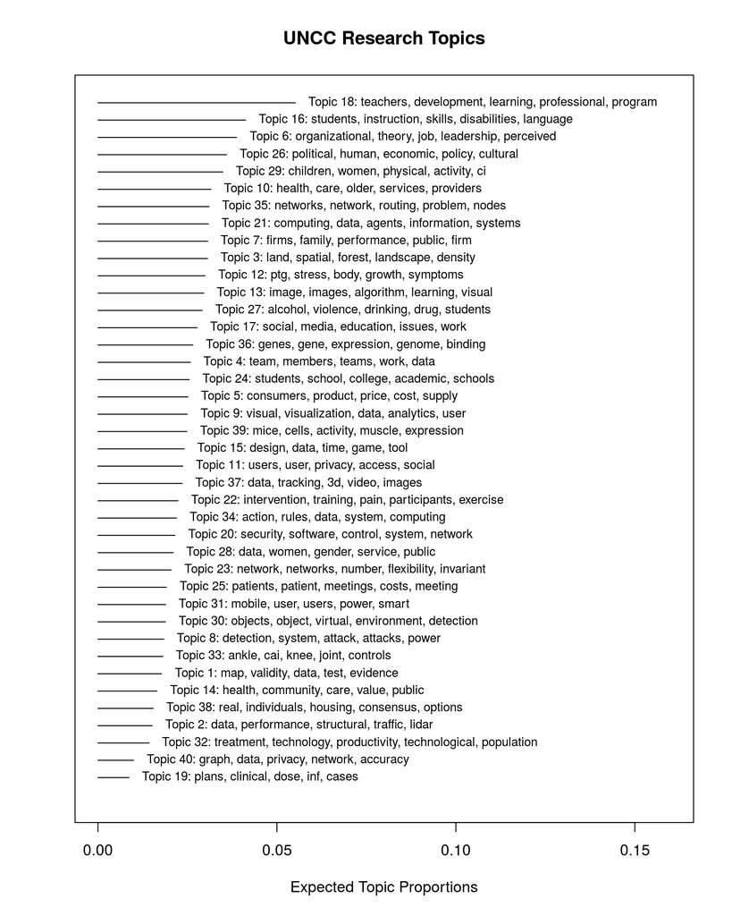

```r
plot(stmFit,
         type = "summary",
         xlim = c(0,.16),
         n = 5,
         labeltype = "prob",
         main = "UNCC Research Topics",
         text.cex = 0.8)
```

We can see almost identical topics – this is a good sign. Our topics are “stable” across runs, even in this case after we added in two prevalent covariates (Year and Subject).

Let’s save our topic information.

```r
topicNames <- labelTopics(stmFit, n = 5)
topic <- data.frame(
  TopicNumber = 1:k,
  TopicProportions = colMeans(stmFit$theta))
```

## Exploring the effects of the covariates: Subject

Next, we want to explore the effect of the covariates on the topic proportions.

First, we’ll need to use the `estimateEffect` function to estimate this effect.

```r
prep <- estimateEffect(1:k ~ Subject + s(Year), stmFit, meta = out$meta, uncertainty = "Global")
```

We can then use the `plot.estimateEffect` function to compare the effect of the “Subject” field (Computing or Social Science binary flag) on topic proportions (likelihood of the topic).

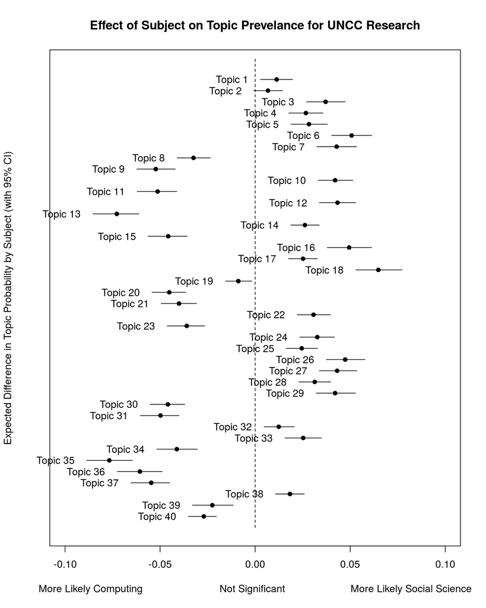

```r
Result <- plot(
  prep,
  "Subject",
  method = "difference",
  cov.value1 = "Social Science",
  cov.value2 = "Computing",
  verbose.labels = F,
  ylab = "Expected Difference in Topic Probability by Subject (with 95% CI)",
  xlab = "More Likely Computing                           Not Significant                       More Likely Social Science",
  main = "Effect of Subject on Topic Prevelance for UNCC Research",
  xlim = c(-0.1, 0.1)
  )
```

Let’s redo this plot but rank the topics.

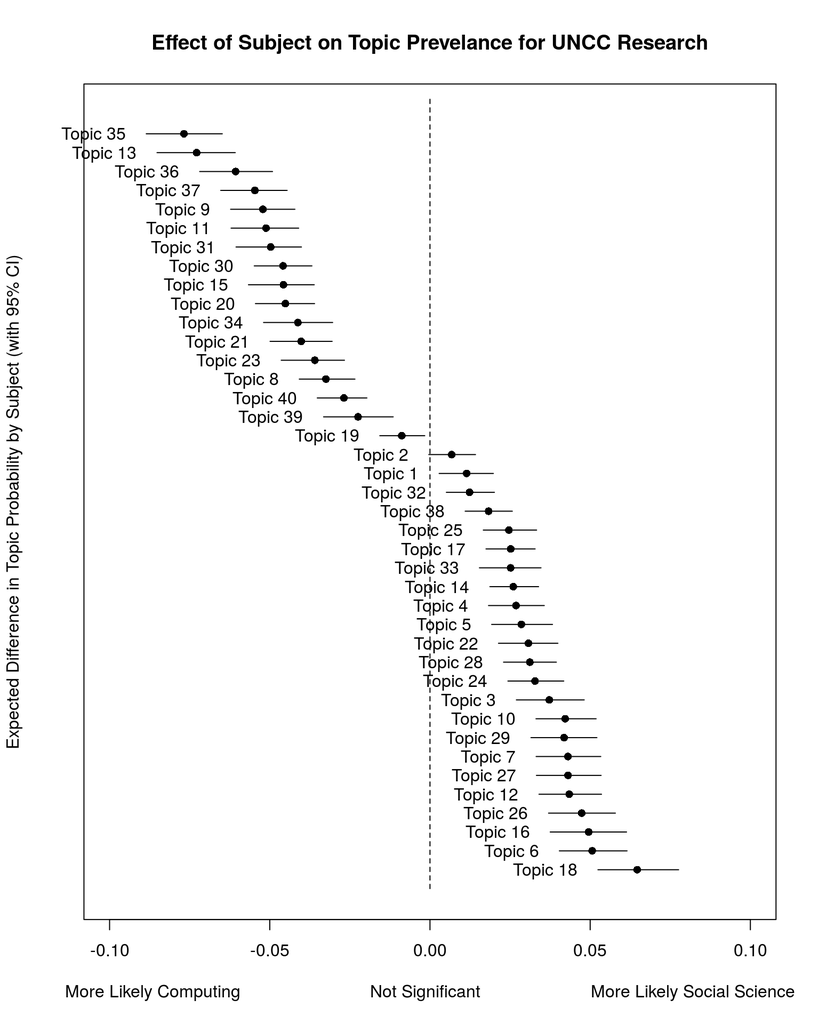

```r
# order based on Expected Topic Proportion
rank = order(unlist(Result$means))
topicRnk <- topic[rank, ]

plot(
  prep,
  "Subject",
  method = "difference",
  cov.value1 = "Social Science",
  cov.value2 = "Computing",
  verbose.labels = F,
  topics = topicRnk$TopicNumber,
  #labeltype = "custom",
  #custom.labels  = apply(topicNames$prob, 1, function(x) paste0(x, collapse = " + ")),
  ylab = "Expected Difference in Topic Probability by Subject (with 95% CI)",
  xlab = "More Likely Computing                           Not Significant                       More Likely Social Science",
  main = "Effect of Subject on Topic Prevelance for UNCC Research",
  xlim = c(-0.1, 0.1)
)
```

## Effect of Time

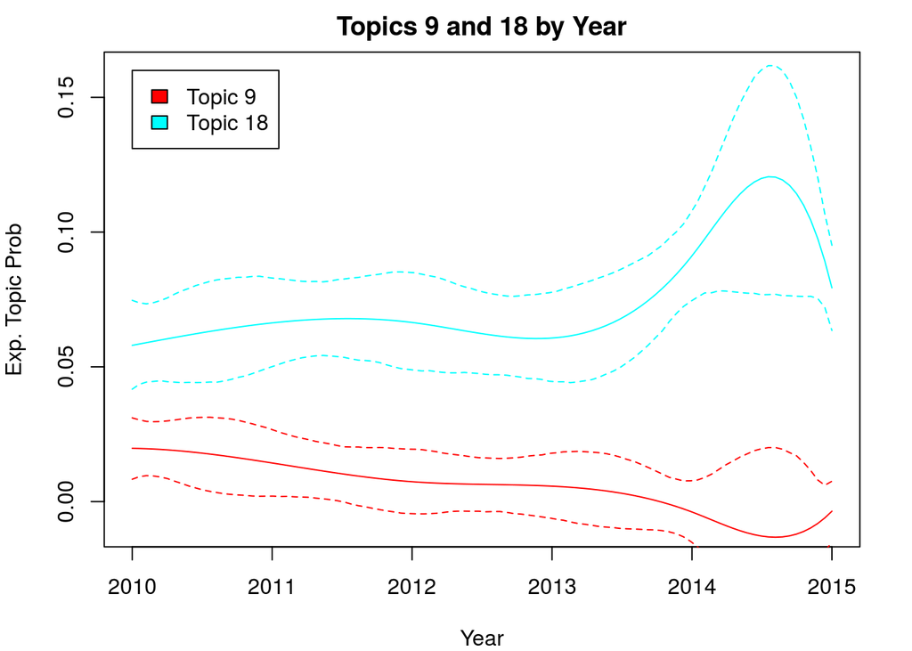

```r
# time
par(mfrow = c(1, 1), mar = c(4, 4, 2, 2))
i <- c(9, 18)
plot(
  prep,
  "Year",
  method = "continuous",
  topics = i,
  main = "Topics 9 and 18 by Year",
  printlegend = T,
  ylab = "Exp. Topic Prob",
  xlab = "Year",
  ylim = c(-0.01, 0.16)
)
```